# Exploratory Data Analysis

Leona Vracar

```r
# Function for analysis of variables
variable_analysis <- function(vect) {
  result <- list(
    mean = mean(vect),
    median = median(vect),
    variance = var(vect),
    sd = sd(vect),
    IQR = IQR(vect),
    min = min(vect),
    max = max(vect),
    range = max(vect) - min(vect)
  )
  return(result)
}

# Format summary statistics as a table
# Execute this on a _result variable (output of variable_analysis(swiss$Fertility)) in a code block to get the  nice table in text)
print_nice <- function(result) {
  # Convert statistics to a formatted table
  table <- as.data.frame(t(as.data.frame(result)))
  colnames(table) <- "Value"  # value is 2nd column
  table <- round(table, 4)

  # Print, left align and title
  knitr::kable(table, caption = "Summary Statistics", align = c("l", "r"))
}
```

```r
# Function for 4 plots: box, histo, QQ, ECDF
plots_function <- function(input_vect, var_name = "default") {
  # mfrow sets 2x2 layout and mar sets plot margins
  par(mfrow = c(2, 2), mar = c(4.5, 4.5, 3, 1))

  #Boxplot
  boxplot(
    input_vect,
    main = paste("Boxplot of", var_name),
    col = "lightgreen",
    horizontal = TRUE
  )

  # Histogram
  hist(
    input_vect,
    main = paste("Histogram of", var_name),
    xlab = var_name,
    col = "lightblue",
    freq = FALSE
  )
  lines(density(input_vect), col = "red", lwd = 2)  #density curve

  # Q-Q
  qqnorm(
    input_vect,
    main = paste("Q-Q Plot of", var_name),
    col = "blue"
  )
  qqline(input_vect, col = "red", lwd = 2)

  # ECDF
  plot(
    ecdf(input_vect),
    main = paste("ECDF of", var_name),
    xlab = var_name,
    ylab = "ECDF"
  )

  # Reset layout back to normal 1x1
  par(mfrow = c(1, 1))
}
```

```r
# Function for outliers check using 1.5 × IQR
calculate_outliers <- function(vect) {
  Q1 <- quantile(vect, 0.25)
  Q3 <- quantile(vect, 0.75)
  IQR <- Q3 - Q1
  result <- list(
    low_fence = Q1 - 1.5 * IQR,
    up_fence = Q3 + 1.5 * IQR
  )
  return(result)
}
```

```r
# function for scatterplot matrix
scatter_matrix <- function(data, main_title = "Scatterplot Matrix", point_color = "darkblue", point_size = 0.8) {
  pairs(
    data,
    main = main_title,
    col = point_color,
    cex = point_size
  )
}
```

```r
# Function for correlation matrix
cor_matrix <- function(data) {
  # Compute cor matrix
  result <- cor(data, use = "pairwise.complete.obs")
  # Print rounded matrix
  print(round(result, 2))

  # make heatmap with dendrogram/colors
  heatmap(
    result,
    main = "Correlation Matrix",
    col = colorRampPalette(c("blue", "white", "red"))(20)
  )
}
```

# 1 Swiss Socioeconomic Data

The dataset swiss contains 6 variables (columns) and 47 rows representing 47 French-spaking provinces of Switzerland at 1888.

The dataset provides information about socioeconomic indicators and fertility for each province.

```r
data(swiss)
head(swiss)
```

```
##              Fertility Agriculture Examination Education Catholic
## Courtelary        80.2        17.0          15        12     9.96
## Delemont          83.1        45.1           6         9    84.84
## Franches-Mnt      92.5        39.7           5         5    93.40
## Moutier           85.8        36.5          12         7    33.77
## Neuveville        76.9        43.5          17        15     5.16
## Porrentruy        76.1        35.3           9         7    90.57
##              Infant.Mortality
## Courtelary               22.2
## Delemont                 22.2
## Franches-Mnt             20.2
## Moutier                  20.3
## Neuveville               20.6
## Porrentruy               26.6
```

## 1.1 EDA of individual variables

In this section, we perform EDA on variables “Fertility”, “Agriculture”, “Education”, “Catholic” and “Infant Mortality”.

```r
fertility_result <- variable_analysis(swiss$Fertility)
agriculture_result <- variable_analysis(swiss$Agriculture)
education_result <- variable_analysis(swiss$Education)
catholic_result <- variable_analysis(swiss$Catholic)
infant_result <- variable_analysis(swiss$Infant.Mortality)
```

### 1.1.1 Fertility

```r
print_nice(fertility_result)
```

Summary Statistics

|  | Value |
| --- | --- |
| mean | 70.1426 |
| median | 70.4000 |
| variance | 156.0425 |
| sd | 12.4917 |
| IQR | 13.7500 |
| min | 35.0000 |
| max | 92.5000 |
| range | 57.5000 |

**Location**: The variable Fertility has a mean of **70.14** and a median of **70.4** suggesting that the data may be symmetric and that there are likely no (or just a few) outliers that skew the dateset (otherwise the mean as a non-robust measure would not so closely match the median).

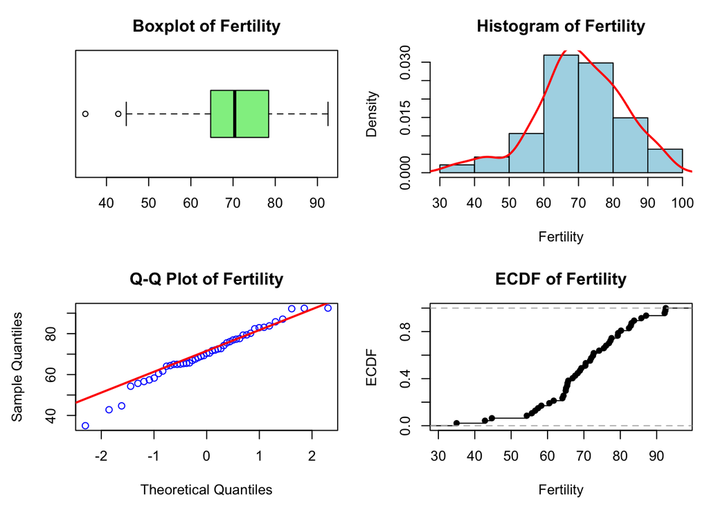

```r
# Call the function
plots_function(swiss$Fertility, var_name = "Fertility")
```

**Boxplot**: In the boxplot, we see **two** potential outliers that lie beyond the central ~95% of the data. However, these two points may not necessarily be outliers since the data is left-skewed (longer whiskers on the left and the location of the median in the left half of the box suggest this skew).

**Histogram**: From the histogram we clearly see the data is not symetrical, is **left-skewed** and unimodal with a single peak. This means that there are potential outliers in the left tail. Most of the data is concentrated around one SD above and below the mean (two largest bars are at 60-80).

**Q-Q Plot**: The left-skew caused by potential outliers is also visible in the Q-Q plot as there are data points deviating from the qqline (normal distribution) at the left end of the plot.

**ECDF**: The steep slope of the ECDF plot around 0.5 (which aligns with the median) also shows that most data-points are concentrated around this value. The curve has a left tail, again due to the two values outside the 95% of the data, one of which is the minimum value of the range at **35**.

In the context of the dataset, it seems that fertility was mostly moderate to high with a few extremes in the lower end of the distribution that could be worth looking into, especially in correlation with other variables.

### 1.1.2 Agriculture

```r
print_nice(agriculture_result)
```

Summary Statistics

|  | Value |
| --- | --- |
| mean | 50.6596 |
| median | 54.1000 |
| variance | 515.7994 |
| sd | 22.7112 |
| IQR | 31.7500 |
| min | 1.2000 |
| max | 89.7000 |
| range | 88.5000 |

**Location**: The mean at **50.66** and median at **54.1** are roughly close together suggesting that the data is close to symmetrical.

**Spread/Variation**: The data has a wider spread compared to fertility with a SD of **22.71** and a wide range of **88.5** from the min value at **1.2** to max value at **89.7**. The middle 50% of data or the IQR is at **31.75**, suggesting that the middle 50% of data is relatively concentrated but with more spread out values beyond the IQR indicated by the SD of **22.71**.

**Skewness**: While the mean and median are pretty close together, the mean is smaller than the median meaning that there might be a left skew in the data pulling the mean slightly down from the central value.

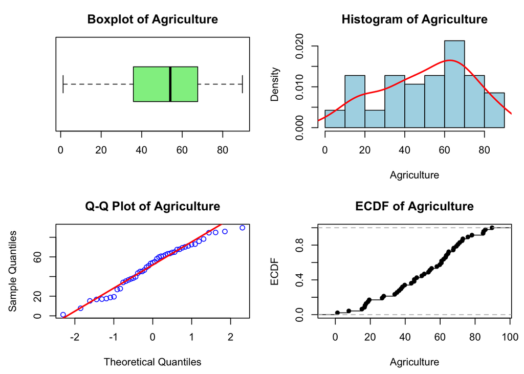

```r
plots_function(swiss$Agriculture, var_name = "Agriculture")
```

**Boxplot**: The length of the left whisker is longer, suggesting a slight left skew. There are no visible outliers in the box plot.

**Histogram**: The slight left skew can also be seen in the histogram. The dataset is unimodal and more widely spread out compared to fertility.

**Q-Q Plot**: The data seems to be very close to a normal distribution, with most points on the qq-line and a few deviations on the left and right end.

**ECDF**: The ECDF-curve has a moderately steep slope, suggesting a wider range.

In the context of the dataset, the lowest value for agriculture **1.2** corresponds to the province “V. De Geneve” which is to be expected as this was an urban center with likely little to no agricultural activities.

#### 1.1.2.1 Extra: Shapiro-Wilks test to check normality

For the null hypothesis, we assume data is approximately normally distributed, while the alternative hypothesis is that data is not normally distributed.

```r
shapiro.test(swiss$Agriculture)
```

```
##
##  Shapiro-Wilk normality test
##
## data:  swiss$Agriculture
## W = 0.96643, p-value = 0.193
```

With a p-value of 0.193, we do not reject the null hypothesis of normality; there is no strong evidence against a normal distribution.

### 1.1.3 Education

```r
print_nice(education_result)
```

Summary Statistics

|  | Value |
| --- | --- |
| mean | 10.9787 |
| median | 8.0000 |
| variance | 92.4561 |
| sd | 9.6154 |
| IQR | 6.0000 |
| min | 1.0000 |
| max | 53.0000 |
| range | 52.0000 |

**Location**: The mean at **10.98** is above the median at **8** suggesting data points which are pulling the mean up from the central value.

**Spread/Variation**: The IQR tells us that 50% of data is in the range of IQR = **6**. Such a tight IQR relative to the min (**1**) and max (**53**) values suggest that half the data is very tightly clustered. The SD of **9.62** is larger than the IQR meaning the SD is inflated by a few larger values.

**Skewness**: As stated, both the mean and SD (as non-robust measures) are inflated upwards compared to the median and IQR (their robust counterparts) which suggests a right skew or a few large outliers.

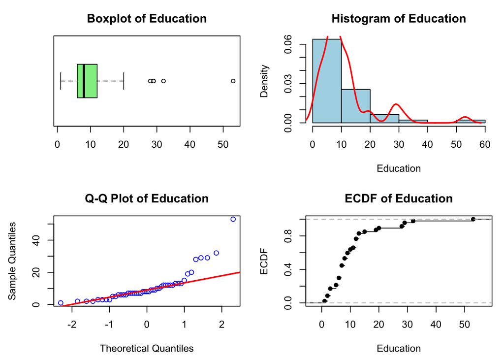

```r
plots_function(swiss$Education, var_name = "Education")
```

**Boxplot**: The boxplot reflects the tight clustering of the data in the IQR (the box) as well as a right skew due to the longer right whisker and four outliers.

**Histogram**: From the density curve, the data looks bimodal with the first peak at the mean and a second one around 30.

**Q-Q Plot**: The higher values deviating from the qqline are also visible on the Q-Q plot. While we only identified 4 in the boxplot, there seem to be several more (6-7) visible in the Q-Q plot. The data does not follow a normal distribution.

**ECDF**: The ECDF is interesting as it shows a steep curve between ~1 and ~15 on the x-axis, with ~15 corresponding to 0.8 on the y-axis, meaning that ~80% of data is in this range (low variability). The long tails at ~20, ~30 and ~50 on the x-axis are extreme values causing the right-skew. In the context of the dataset, this means that most people (in 1888) had a low-level of education with just a few having higher levels. The max value of **53** matches the min value for agriculture and corresponds to the province “V. De Geneve” which likely had a more educated population due to being an urban center.

### 1.1.4 Catholic

```r
print_nice(catholic_result)
```

Summary Statistics

|  | Value |
| --- | --- |
| mean | 41.1438 |
| median | 15.1400 |
| variance | 1739.2945 |
| sd | 41.7049 |
| IQR | 87.9300 |
| min | 2.1500 |
| max | 100.0000 |
| range | 97.8500 |

**Location**: The mean at **41.14** and median at **15.14** differ significantly which means the data is not symmetrical. Since the mean >> median, there are likely several extreme data points in the higher end of the distribution affecting the mean.

**Spread/Variation**: The IQR as a robust measure at **87.93** and the high SD as a non-robust one at **41.7** signify a broad distribution and highly variable data. This is further confirmed by broad range (**97.85**) between min at **2.15** and max at **100**.

**Skewness**: The data is likely bimodal or right-skewed due to the mean being significantly higher than the median.

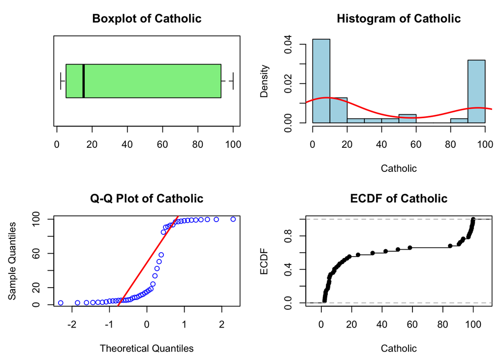

```r
plots_function(swiss$Catholic, var_name = "Catholic")
```

**Boxplot**: The median is very close to the lower quartile (Q1) in the box meaning that most data points are likely in the lower range. There are no visual outliers but the distribution is very stretched out and the right whisker together with the position of the median suggest a right skew.

**Histogram**: The histogram has 2 peaks i.e. a bimodal distribution. Very few values are in the central part of the range (between 30 and 70). The density curve may be a bit misleading because it doesn’t show the sharp peaks visible in the bars.

**Q-Q Plot**: The data is clearly bimodal. The tail in the low end (negative quantiles on the x-axis) is below the normalcy line which suggests smaller values compared to a normal distribution. Most data points are in this lower end with the median (at 0 quantile on the x-axis) being significantly below the expected median value for a normal distribution. The higher end of the data (between ~0.5-2 quantiles on x-axis) show the higher end of the bimodal distribution.

**ECDF**: This plot confirms that the data is bimodal with most values (~0.6 on y-axis or 60%) being in a narrow lower range, a few dispersed values in the mid-range and another distinct peak (~0.75 on y-axis or at 75%) in the high range.

In the context of the dataset, the bimodal distribution means that most provinces were either completely non-Catholic or close to 100% Catholic. However, we do not have the data about the population size of each province so we cannot make any statements about the the absolute number of Christians or non-Christians per province. For example, the max value of **100** corresponding to the province Herens makes it seem like 100% of the inhabitants are Christian but there may only be a very small population living in this province.

### 1.1.5 Infant mortality

```r
print_nice(infant_result)
```

Summary Statistics

|  | Value |
| --- | --- |
| mean | 19.9426 |
| median | 20.0000 |
| variance | 8.4838 |
| sd | 2.9127 |
| IQR | 3.5500 |
| min | 10.8000 |
| max | 26.6000 |
| range | 15.8000 |

**Location**: The mean (**19.94**) and median (**20**) are almost identical, suggesting symmetrical data with little to no outliers.

**Spread/Variation**: Both the SD at **2.91** and IQR at **3.55** suggest low variability of data with most data points centered around the mean/median. However, since SD is slightly lower than the IQR and the data ranges from **10.8** (min) to **26.6** (max), there may be some low values present that slightly push the SD down.

**Skewness**: No indication of skewness.

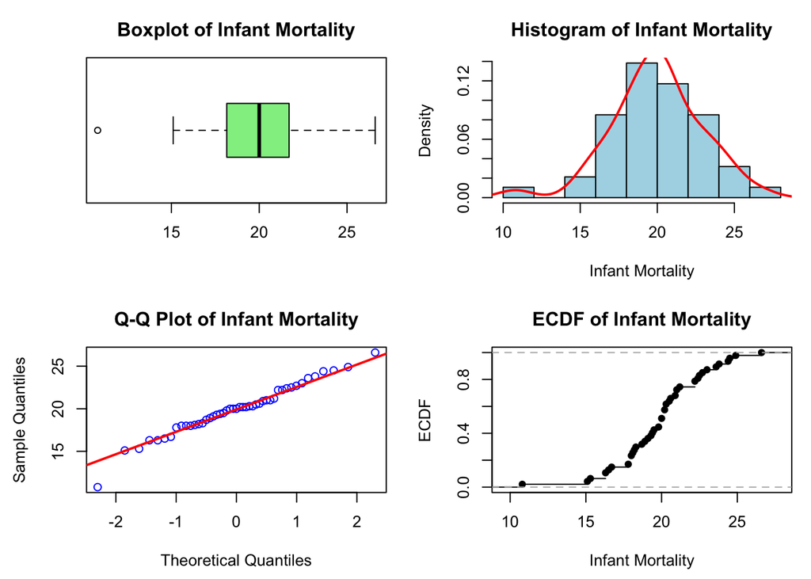

```r
plots_function(swiss$Infant.Mortality, var_name = "Infant Mortality")
```

**Boxplot**: The boxplot shows an outlier which is the min value of **10.8** corresponding to the province La Vallee.

**Checking the min value as potential outlier**

```r
infant_outliers <- calculate_outliers(swiss$Infant.Mortality)
infant_outliers
```

```
## $low_fence
##    25%
## 12.825
##
## $up_fence
##    75%
## 27.025
```

Using the Q1 - IQR * 1.5 (lower fence at **12.82**) and Q3 + IQR * 1.5 (upper fence at **27.02**), we see that the min value lies outside this range and is technically an outlier. However, this entry is worth examining further as a data point with some additional significance (also in relation to other variables).

**Histogram**: The data shows a normal distribution except for the aforementioned outlier/min value.

**Q-Q Plot**: This plot also confirms normalcy of the data as the individual points are on the qqline.

**ECDF**: Also shows normal distribution of data excluding the min value.

## 1.2 Correlation between variables

**Scatterplot Matrix**

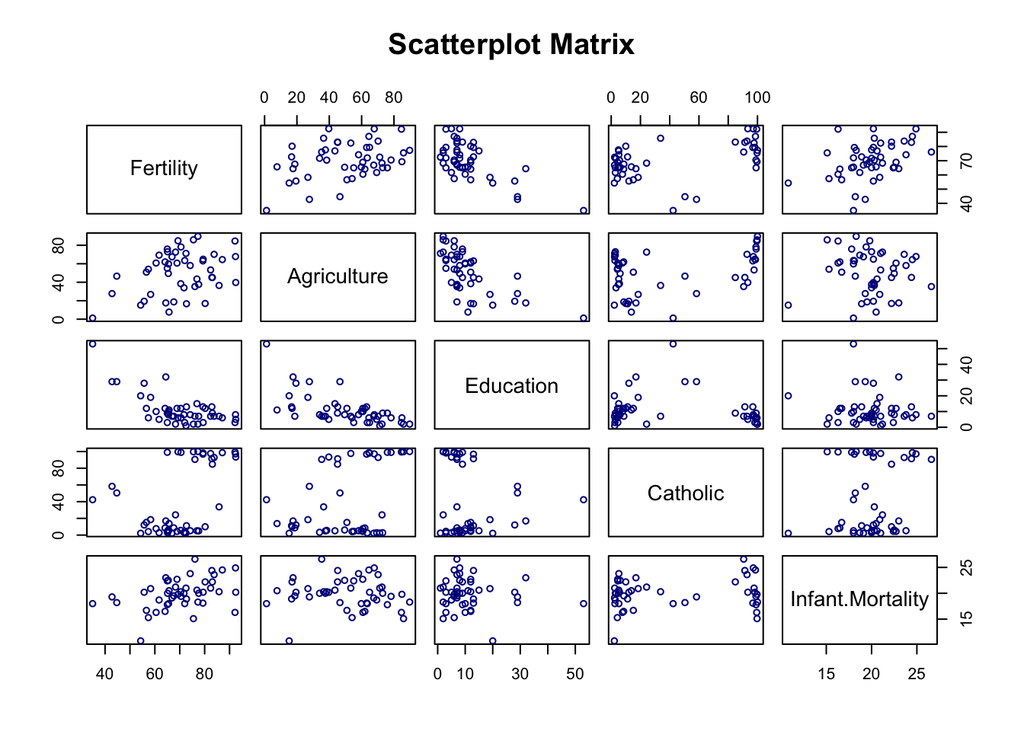

```r
# Selecting variables (making a subset of those that we're interested in)
swiss_subset <- swiss[, c("Fertility", "Agriculture", "Education", "Catholic", "Infant.Mortality")]

# Scatterplot matrix
scatter_matrix(swiss_subset)
```

The scatterplot matrix shows visible patterns between some variables:

1. Fertility and Agriculture seem to have a positive correlation.
2. Fertility and Education seem to have a negative correlation.
3. Infant mortality and Fertility seem to have a positive correlation.
4. Agriculture and Education seem to have a negative correlation.

To examine these correlations further, we look at a correlation matrix in the next step.

**Correlation Matrix**

```r
cor_matrix(swiss_subset)
```

```
##                  Fertility Agriculture Education Catholic Infant.Mortality
## Fertility             1.00        0.35     -0.66     0.46             0.42
## Agriculture           0.35        1.00     -0.64     0.40            -0.06
## Education            -0.66       -0.64      1.00    -0.15            -0.10
## Catholic              0.46        0.40     -0.15     1.00             0.18
## Infant.Mortality      0.42       -0.06     -0.10     0.18             1.00
```

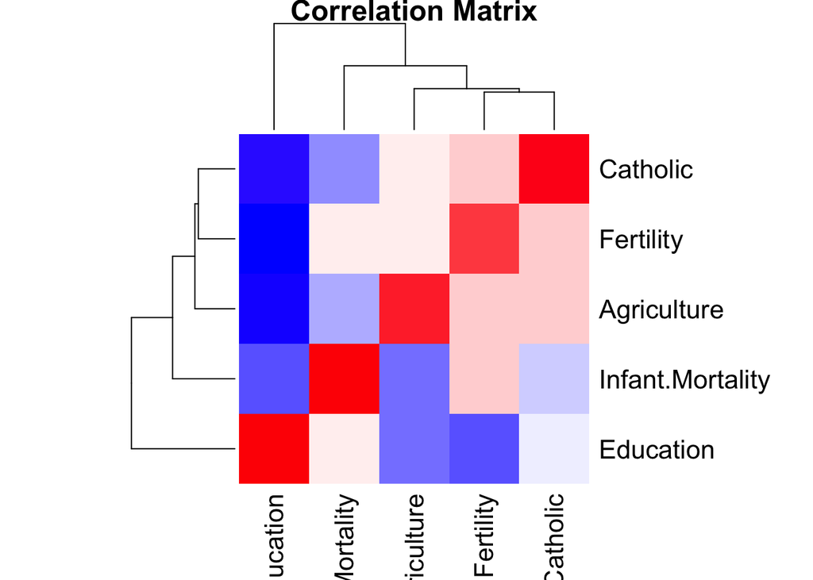

The correlation matrix confirms the correlations we already identified and additionally shows a positive correlation between Fertility and Catholic (r = 0.46).

Some possible conclusions from the correlations are:

**Fertility, Agriculture and Education**: Swiss provinces with higher rates of agricultural activity had a higher fertility rate while education and fertility were negatively correlated (r = -0.66). In addition, education and agriculture were strongly negatively correlated (r = -0.64), suggesting that education levels were lower in rural areas and higher in urban areas. These findings are in line with common demographic patterns where lower birth rates are associated with higher education levels.

**Catholic**: One somewhat peculiar finding was the positive correlation between Catholic and Fertility (r = 0.46) suggesting that Catholic provinces had higher fertility rates. Catholicism rates also had a positive correlation with Agriculture (r = 0.40) suggesting that more agricultural communities were more religious and had a higher rate of fertility.

# 2 US State Demographic Data

The state.x77 dataset includes various statistics (population, income, illiteracy etc.) from the 1970s for each USA-state.

```r
state.x77_dataframe <- as.data.frame(state.x77)
head(state.x77_dataframe, 7)
```

```
##             Population Income Illiteracy Life Exp Murder HS Grad Frost   Area
## Alabama           3615   3624        2.1    69.05   15.1    41.3    20  50708
## Alaska             365   6315        1.5    69.31   11.3    66.7   152 566432
## Arizona           2212   4530        1.8    70.55    7.8    58.1    15 113417
## Arkansas          2110   3378        1.9    70.66   10.1    39.9    65  51945
## California       21198   5114        1.1    71.71   10.3    62.6    20 156361
## Colorado          2541   4884        0.7    72.06    6.8    63.9   166 103766
## Connecticut       3100   5348        1.1    72.48    3.1    56.0   139   4862
```

## 2.1 EDA of individual variables

This section explores the variables “Population”, “Income”, “Illiteracy”, “Life.Exp”, “Murder”, “HS Grade” and “Frost”.

```r
pop_result <- variable_analysis(state.x77_dataframe$Population)
inc_result <- variable_analysis(state.x77_dataframe$Income)
illi_result <- variable_analysis(state.x77_dataframe$Illiteracy)
life_exp_result <- variable_analysis(state.x77_dataframe$`Life Exp`)
murder_result <- variable_analysis(state.x77_dataframe$Murder)
hs_grad_result <- variable_analysis(state.x77_dataframe$`HS Grad`)
frost_result <- variable_analysis(state.x77_dataframe$Frost)
```

### 2.1.1 Population

```r
print_nice(pop_result)
```

Summary Statistics

|  | Value |
| --- | --- |
| mean | 4246.420 |
| median | 2838.500 |
| variance | 19931683.759 |
| sd | 4464.491 |
| IQR | 3889.000 |
| min | 365.000 |
| max | 21198.000 |
| range | 20833.000 |

**Location**: The mean at **4246.42** and median at **2838.5** diverge significantly which suggests the data is not symmetrical. Median is robust and hence appropriate as the locus for this dataset.

**Spread**: The data has a high variance **1.9931684^{7}** and standard deviation **4464.49** which means the population numbers are widely different across states. The IQR of 3889 means that the middle 50% of states have populations in this range.

**Skewness**: The data is skewed to the right since mean >> median.

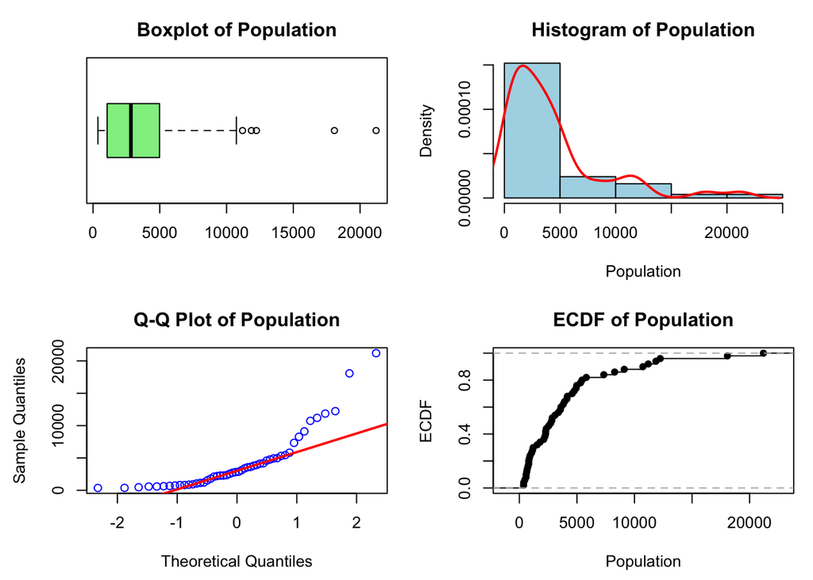

```r
plots_function(state.x77_dataframe$Population, var_name = "Population")
```

**Boxplot**: Outliers are visible beyond the right whisker, 3 potential outliers and 2 definite ones. The elongated right whisker also suggests a right skew.

**Histogram**: The right-skew is clearly visible in the histogram. Most states have a population up to 7000, while there are a few ones with larger population numbers between 10 000 and 25 000. It could be argued that the data is unimodal with several outliers or the outliers could be grouped together in a cluster in a bimodal dataset since population is (unsurprisingly) higher in more urban states like California and New York.

**Q-Q Plot**: The dataset deviates from a normal distribution, especially at the upper end. Again, the deviation is caused by the outliers.

**ECDF**: The ECDF plot shows a steep rise in the beginning, meaning many states have low populations. The more elongated points at the right of the plot are the few states with large populations.

### 2.1.2 Income

```r
print_nice(inc_result)
```

Summary Statistics

|  | Value |
| --- | --- |
| mean | 4435.8000 |
| median | 4519.0000 |
| variance | 377573.3061 |
| sd | 614.4699 |
| IQR | 820.7500 |
| min | 3098.0000 |
| max | 6315.0000 |
| range | 3217.0000 |

**Location**: The median at **4519** and mean at **4435.8** are close together, hence the data is likely symmetrical. From the plots below, there seems to be a single potential outlier in the higher range of incomes but the median is still a fitting measure of central tendency for this variable.

**Spread**: The per capita income has a moderate spread with a sd of **614.47**. The robust measures: range of **3217** and IQR of **820.75**.

**Skewness**: The data approximately follows a normal distribution.

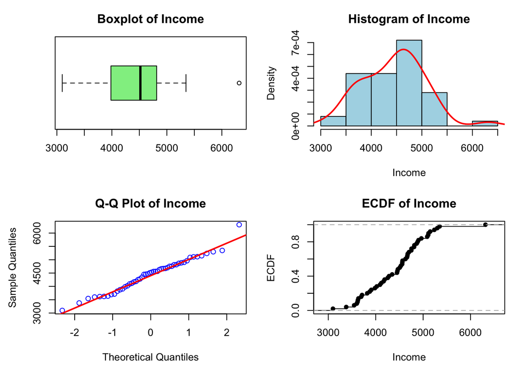

```r
plots_function(state.x77_dataframe$Income, var_name = "Income")
```

**Boxplot**: A single outlier is visible in the high range. The central 50% of per-capita incomes are between 4000 and 5000 USD.

**Histogram**: The data is unimodal and approximately normally distributed.

**Q-Q Plot**: The normal distribution is also confirmed by the Q-Q plot.

**ECDF**: Smooth, S-shaped curve, indicating a gradual increase in values. Most incomes are between ~3500 and ~5000.

### 2.1.3 Illiteracy

```r
print_nice(illi_result)
```

Summary Statistics

|  | Value |
| --- | --- |
| mean | 1.1700 |
| median | 0.9500 |
| variance | 0.3715 |
| sd | 0.6095 |
| IQR | 0.9500 |
| min | 0.5000 |
| max | 2.8000 |
| range | 2.3000 |

**Location**: Both the mean at **1.17** and the median at **0.95** are low and pretty close together without any outliers. While the mean is appropriate here as a measure of central tendency, it is slightly higher than the median, potentially indicating a slight right-skew.

**Spread**: Considering that the illiteracy rate is a percentage of the population of the respective state (and hence could technically take up values 0-100%), the data has low variability and a tight spread. The min at **0.5** and max at **2.8** confirm this. At most, the illiteracy rate is at 2.8% which is indicative of the fact that the US population across all states was highly literate in the 1970s.

**Skewness**: Illiteracy is slightly right-skewed, meaning most states had low illiteracy, but a few had significantly higher rates as visible in the right whisker of the boxplot and the density curve of the histogram. However, it is crucial to interpret the data in its context here. Considering that illiteracy could take up values between 0-100% and the right-skew is caused by a few values between ~ 1.6% illiteracy (displayed by the right whisker in the box plot) and the max value of 2.8%, illiteracy still remains very low overall.

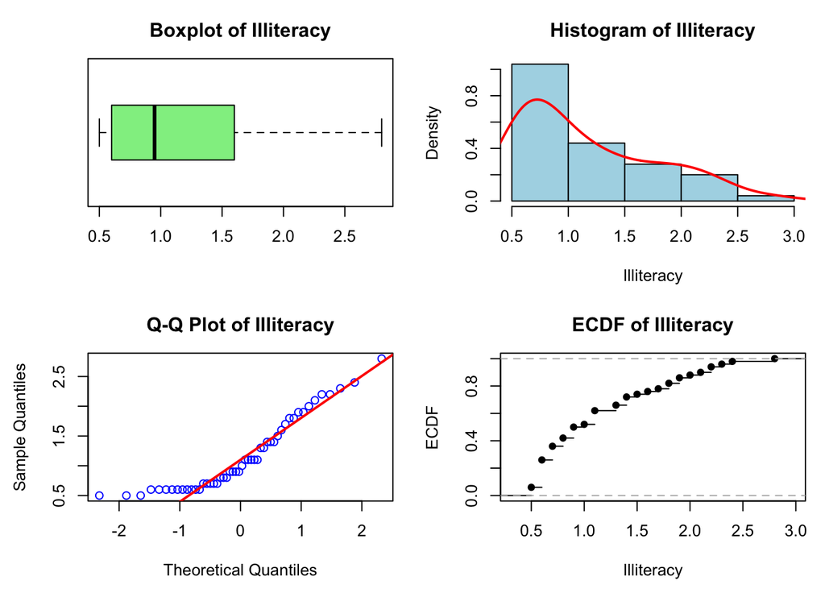

```r
plots_function(state.x77_dataframe$Illiteracy, var_name = "Illiteracy")
```

**Boxplot**: There are no extreme outliers, suggesting no states with high illiteracy rates.

**Histogram**: The highest bar contains values between 0.5 and 1%. The data has a right skew and is unimodal.

**Q-Q Plot**: The data is approximately normally distributed with a slight deviation in the bottom range.

**ECDF**: Around 60% of states have illiteracy below 1.5%, as seen by the more steep rise before 1.5.

### 2.1.4 Life Expectancy

```r
print_nice(life_exp_result)
```

Summary Statistics

|  | Value |
| --- | --- |
| mean | 70.8786 |
| median | 70.6750 |
| variance | 1.8020 |
| sd | 1.3424 |
| IQR | 1.7750 |
| min | 67.9600 |
| max | 73.6000 |
| range | 5.6400 |

**Location**: The mean at **70.88** and median at **70.67** are almost identical which suggests highly symmetrical data.

**Spread**: The standard deviation at **1.34** is ~23% of the total range (**5.64**) suggesting a tight to moderate spread relative to the range. The IQR of **1.78** as a robust measure confirms this. In the context of life expectancy, most values are concentrated around the mean.

**Skewness**: Data appears to be symmetrical with no outliers nor skewness.

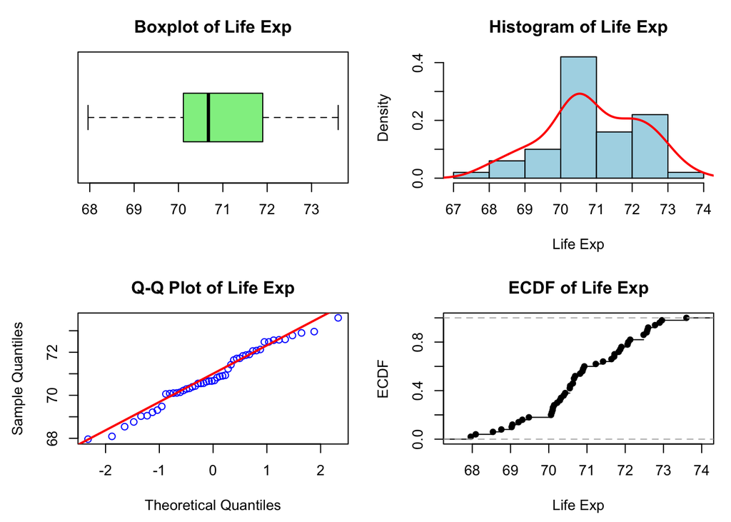

```r
plots_function(state.x77_dataframe$`Life Exp`, var_name = "Life Exp")
```

**Boxplot**: No outliers and approximately symmetrical data.

**Histogram**: Data appears to be unimodal and approximately normally distributed. Three tallest bars are in the 70-73 range, which sum up to ~75% on the density on the y-axis. Hence, a large majority of states have life expectancies in this range.

**Q-Q Plot**: This plot confirms that life expectancy follows a normal distribution with only a few minor deviations at the upper/lower end.

**ECDF**: Pretty smooth curve which gets steeper at LifeExp = 70 and then flattens out again around LifeExp = 73. This confirms that the top ~75% of data is located in this range.

### 2.1.5 Murder Rate

```r
print_nice(murder_result)
```

Summary Statistics

|  | Value |
| --- | --- |
| mean | 7.3780 |
| median | 6.8500 |
| variance | 13.6275 |
| sd | 3.6915 |
| IQR | 6.3250 |
| min | 1.4000 |
| max | 15.1000 |
| range | 13.7000 |

**Location**: The mean (**7.38**) is slightly higher than the median (**6.85**), indicating mild right skewness. The mean may still be appropriate as the central tendency of the data.

**Spread**: The range (**13.7**) is pretty large relative to the central tendency, suggesting a wider spread of data.

**Skewness**: As visible in the plots, the data is not skewed but bimodal with a second peak which is displacing the mean upwards compared to the median.

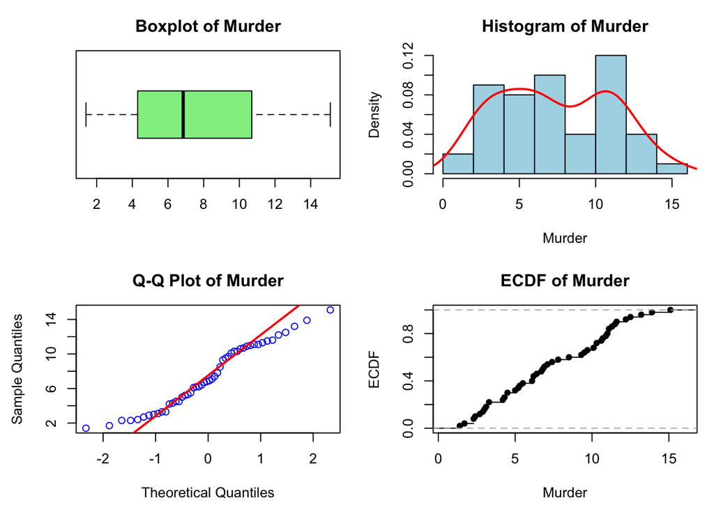

```r
plots_function(state.x77_dataframe$Murder, var_name = "Murder")
```

**Boxplot**: No visible outliers and approximately symmetrical data. The right whisker is longer which means that more values are found in the upper 25% of data compared to the lowest 25%.

**Histogram**: There are two clear peaks in the histogram, one between Murder ~3 to ~6.5 and a second one between ~10 and ~12. Hence, murder appears to be bimodal with ~30% of states exhibiting a higher murder rate per 100 000 inhabitants compared to the rest of the data contained in the first mode which have murder rates lower than 10.

**Q-Q Plot** and **ECDF**: The bimodality of the data is visible in both the Q-Q plot and the ECDF. The ECDF is particularly interesting as it clearly shows a gradual rise of the curve from around 0 to 7, then a brief plateau follower by a second steep rise in the 10-12 range. The Q-Q plot shows significant deviations from normality beyond 10 on the y-axis (sample quantlies) which corresponds to the second peak in the bimodal distribution.

In the context of the dataset, murder rates seem to be surprisingly high in some states compared to the rest of the country.

### 2.1.6 HS Graduation Rate

```r
print_nice(hs_grad_result)
```

Summary Statistics

|  | Value |
| --- | --- |
| mean | 53.1080 |
| median | 53.2500 |
| variance | 65.2379 |
| sd | 8.0770 |
| IQR | 11.1000 |
| min | 37.8000 |
| max | 67.3000 |
| range | 29.5000 |

**Spread**: The data has a wide spread between min = **37.8** and max = **67.3** (range = **29.5**).

**Skewness**: No indication of skewness.

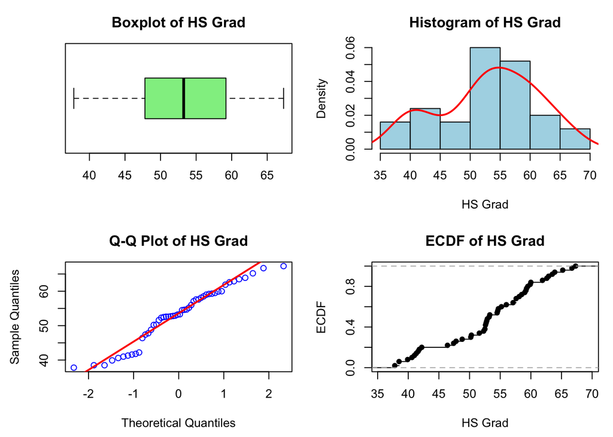

```r
plots_function(state.x77_dataframe$`HS Grad`, var_name = "HS Grad")
```

**Boxplot**: The boxplot, on its own, suggests almost perfect symmetry but the other plots clearly indicate bimodality.

**Histogram**: The histogram reveals two peaks: a smaller one in the lower range and a larger peak in the higher range. This means that the percentage of high school graduates in most states is between ~50-60%. However, a smaller but non-negligible number of states have lower high school graduation rates in the ~38-43% range.

**Q-Q Plot** and **ECDF**: The Q-Q plot shows that the data strongly deviates from a normal distribution, especially in the lower range which corresponds to the first mode. The ECDF illustrates the separation of the two peaks: a short but steep curve of the first mode is followed by a plateau between ~43 and ~46 on the x-axis, followed by a second curve with a more gradual increase but a small steep rise at ~53. The small steep rise at ~53 on the ECDF curve signifies that there is a concentration of data at this point which may be part of the reason why the mean also has this value and wasn’t displaced from the median by the bimodal distribution.

### 2.1.7 Frost

The frost variable is the mean number of days with minimum temperature below freezing (1931-1960) in capital or large city.

```r
print_nice(frost_result)
```

Summary Statistics

|  | Value |
| --- | --- |
| mean | 104.4600 |
| median | 114.5000 |
| variance | 2702.0086 |
| sd | 51.9808 |
| IQR | 73.5000 |
| min | 0.0000 |
| max | 188.0000 |
| range | 188.0000 |

**Location**: The mean (**104.46**) and (**114.5**) differ by 10 days which suggests that there are low values displacing the mean below the median. The mean approximates the central tendency of the data but the median is more reliable as the locus in this case.

**Spread**: The standard deviation (**51.98**) is large relative to the overall range of the data (**188**), meaning that the data is highly spread out and variable.

**Skewness**: From the histogram and Q-Q plot we can conclude that the data is actually bimodal with some states having low numbers of days with freezing temperatures (e.g. Hawaii, our min value of 0).

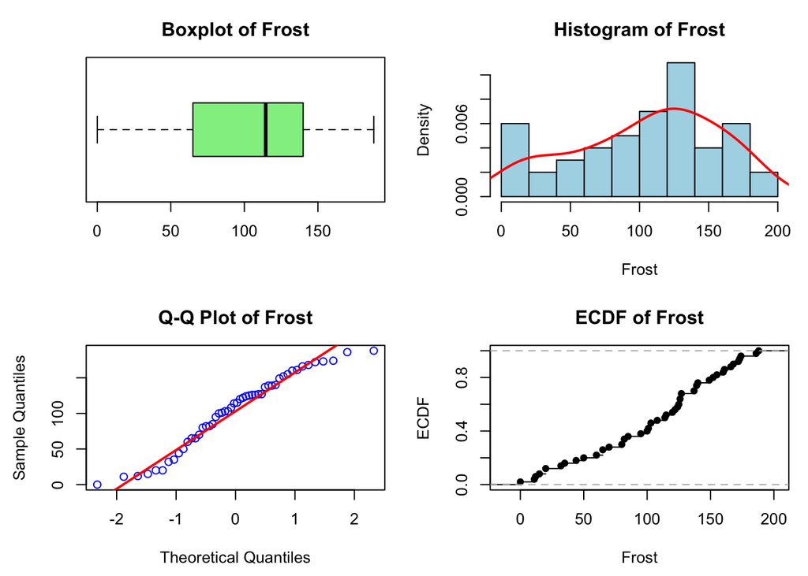

```r
plots_function(state.x77_dataframe$Frost, var_name = "Frost")
```

**Boxplot**: The boxplot is not a useful visualization for this data as it does not show the bimodal distribution. The only useful information we can deduce is that the slightly longer left whisker means there are several states with little to no days with below-freezing temperatures.

**Histogram**: The density curve is misleading as it smooths out the first peak of the bimodal distribution i.e. the data contained in the first bar. However the histogram bars are the best visualization here for the bimodallity of the data.

**Q-Q Plot**: The Q-Q plot on its own it would not clearly indicate bimodality as most points fall close to the red qqline. However, the typical S-shaped curve of a bimodal distribution is still visible in the Q-Q plot, albeit its S-shape is more flattened out and may be difficult to notice at first glance.

**ECDF**: Similarly, the ECDF plot barely makes the bimodal distribution visible. It is possible to identify a clear second mode around 130 on the x-axis but the first mode is barely distinguishable between 5 and 10.

## 2.2 Correlation between variables

### 2.2.1 Scatterplot Matrix

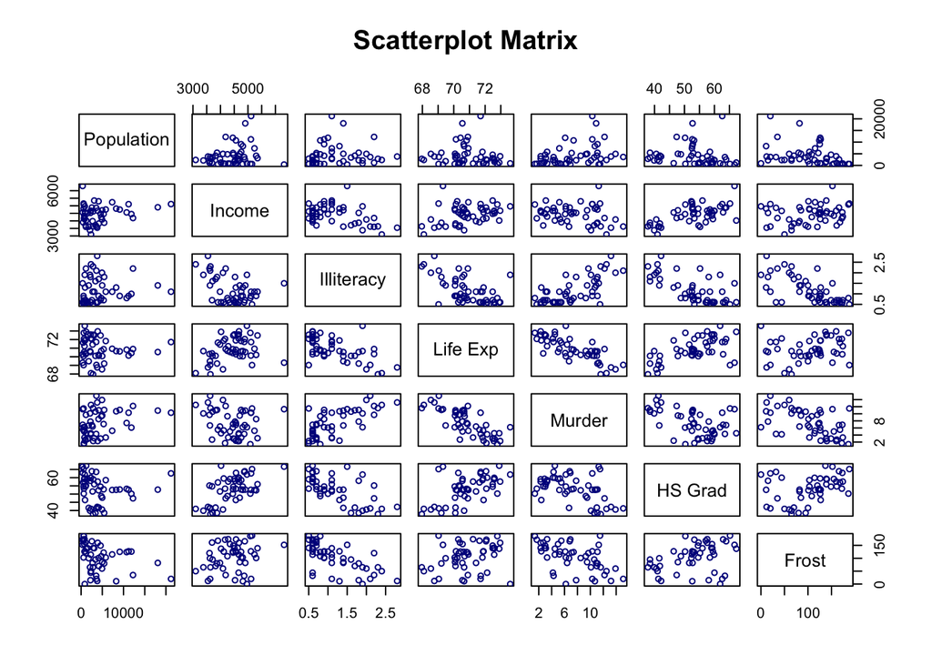

```r
usa_subset <- state.x77[, c("Population", "Income", "Illiteracy", "Life Exp",
                            "Murder", "HS Grad", "Frost")]
# Scatterplot matrix
scatter_matrix(usa_subset)
```

### 2.2.2 Correlation Matrix

```r
cor_matrix(usa_subset)
```

```
##            Population Income Illiteracy Life Exp Murder HS Grad Frost
## Population       1.00   0.21       0.11    -0.07   0.34   -0.10 -0.33
## Income           0.21   1.00      -0.44     0.34  -0.23    0.62  0.23
## Illiteracy       0.11  -0.44       1.00    -0.59   0.70   -0.66 -0.67
## Life Exp        -0.07   0.34      -0.59     1.00  -0.78    0.58  0.26
## Murder           0.34  -0.23       0.70    -0.78   1.00   -0.49 -0.54
## HS Grad         -0.10   0.62      -0.66     0.58  -0.49    1.00  0.37
## Frost           -0.33   0.23      -0.67     0.26  -0.54    0.37  1.00
```

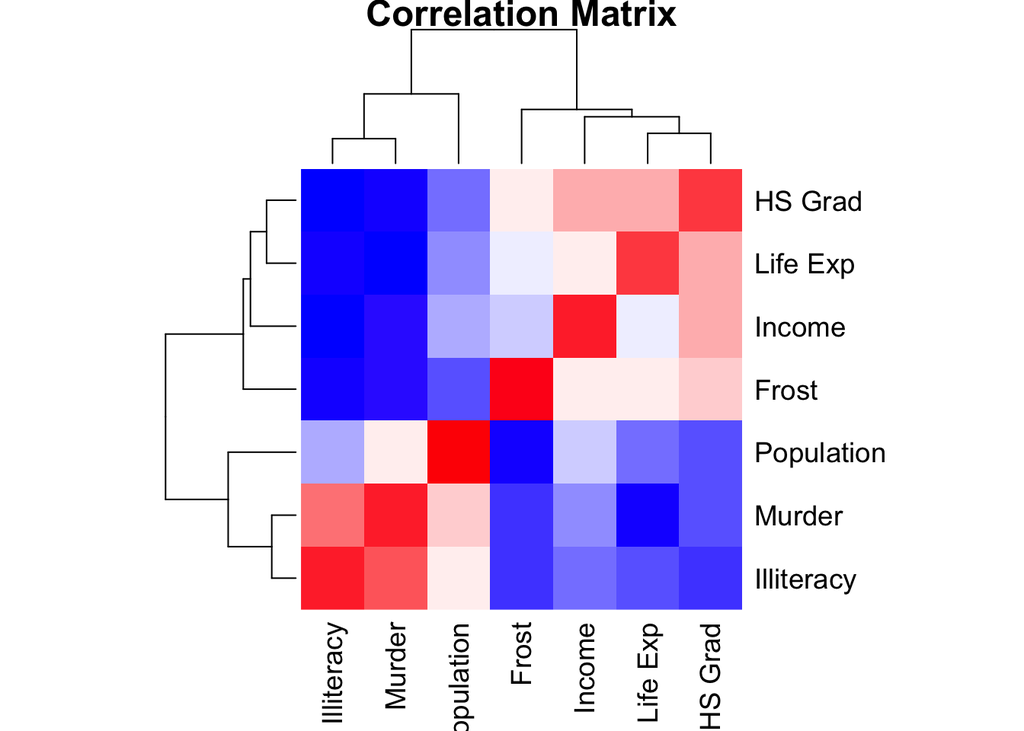

In this part, we look at some interesting correlations between the variables:

**Illiteracy and Murder Rate (0.70)**: A strong positive correlation suggests that states with higher illiteracy rates tend to have higher murder rates. This relationship should not be interpreted causally.

**Illiteracy and Life Expectancy (-0.59)**: The negative correlation implies that states with higher illiteracy rates tend to have lower life expectancy. We can speculate that illiteracy likely doesn’t exist in isolation but that it is the result of generally worse economic conditions and less access to things such as healthcare, balanced food or even free time to learn to read and write. Hence, illiteracy probably doesn’t lower life expectancy on its own but it signifies a larger issue like poverty in these states which leads to lower life expectancy and more crime.

**Murder Rate and Life Expectancy (-0.78)**: A strong negative correlation indicates that states with higher murder rates have lower life expectancy, which is not surprising and maybe shows that there are public safety issues in these states.

**HS Graduation Rate and Life Expectancy (0.58)**: A positive correlation suggests that states with higher high school graduation rates also tend to have longer life expectancy. Again, we cannot make the conclusion that graduating high school increases life expectancy but the positive correlation may point to other societal issues which cause people to not graduate high school such as worse living conditions which in turn may lower life expectancy.

**Income and HS Graduation Rate (0.62)**: A moderately strong positive correlation suggests that states with higher average income levels tend to have higher high school graduation rates, which makes sense as richer states may have more funding for education, more people can afford education and access it more easily.

**Frost and Murder Rate (-0.54)**: A negative correlation suggests that colder states (those with more frost days) tend to have lower murder rates.

**Population and Murder Rate (0.34)**: A weak positive correlation suggests that more populous states tend to have slightly higher murder rates maybe because crime is often concentrated in big cities.

# 3 Lake Huron Time-Series Data

The dataset LakeHuron contains annual measurements of the level of Lake Huron 1875-1972 (in feet).

```r
LakeHuron <- LakeHuron
```

## 3.1 EDA of lake levels

### 3.1.1 Lake levels without considering the time aspect

```r
# To analyze just the lake levels we convert them to a numeric vector
# LakeHuron is a ts object in R
lake_levels <- as.numeric(LakeHuron)

levels_result <- variable_analysis(lake_levels)
print_nice(levels_result)
```

Summary Statistics

|  | Value |
| --- | --- |
| mean | 579.0041 |
| median | 579.1200 |
| variance | 1.7379 |
| sd | 1.3183 |
| IQR | 1.7400 |
| min | 575.9600 |
| max | 581.8600 |
| range | 5.9000 |

**Location**: The mean (**579**) and median (**579.12**) are close to being identical which suggests a high level of symmetry and no outliers or extreme values.

**Spread**: The data has a moderate range (**5.9**) and moderate spread. The middle 50% of data is also pretty concentrated with an IQR of **1.74**.

**Skewness**: The mean is slightly lower than the median which suggests that a few values below the median may be causing a slight deviation from symmetry. However, the data still appears to be very close to perfect symmetry.

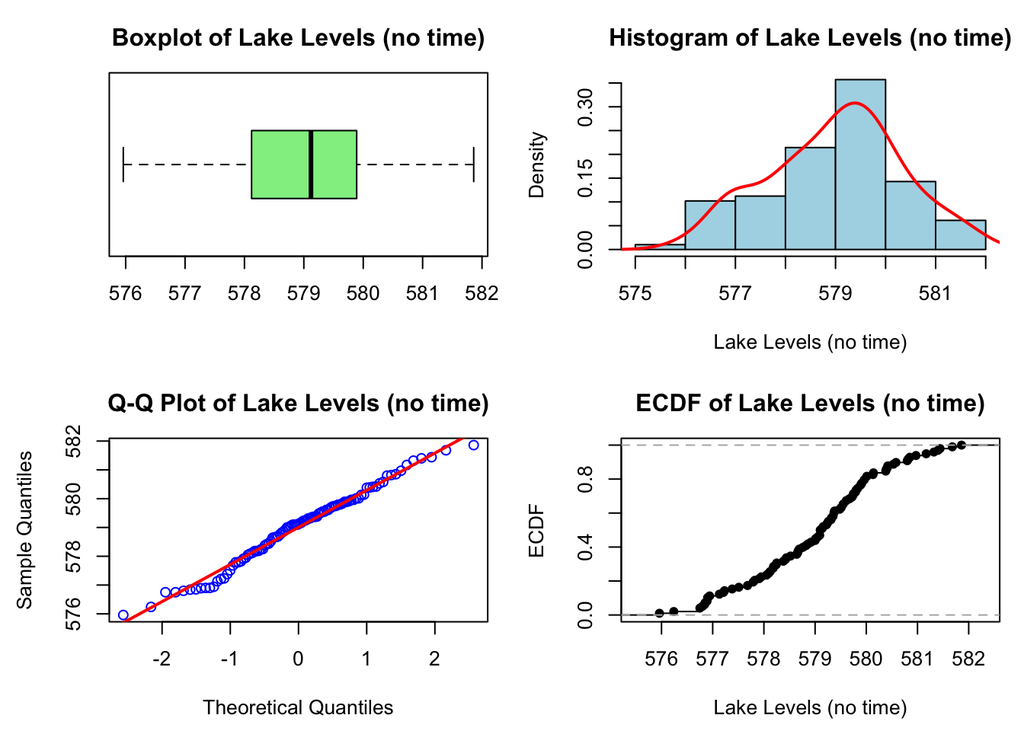

```r
plots_function(lake_levels, var_name = "Lake Levels (no time)")
```

**Boxplot**: A few more data points below the median (the black line) can be deduced from the boxplot. Besides this, the data seems symmetric with no outliers.

**Histogram**: Data is approximately symmetric and unimodal with a very slight left tail but not nearly enough to identify skewness.

**Q-Q Plot**: Data is normally distributed with just a few deviations from the red qqline at the extremes.

**ECDF**: The ECDF is smooth and continuous, indicating no outliers.

### 3.1.2 Lake levels including the time aspect

From the time series plot above, there seems to be a decline in water levels as time progresses. However, we can’t say if this decline is significant at this stage of analysis.

Another interesting element in this data is that the max value was recorded in the first few years of measurements while the lowest water level was recorded near the end around 1965.

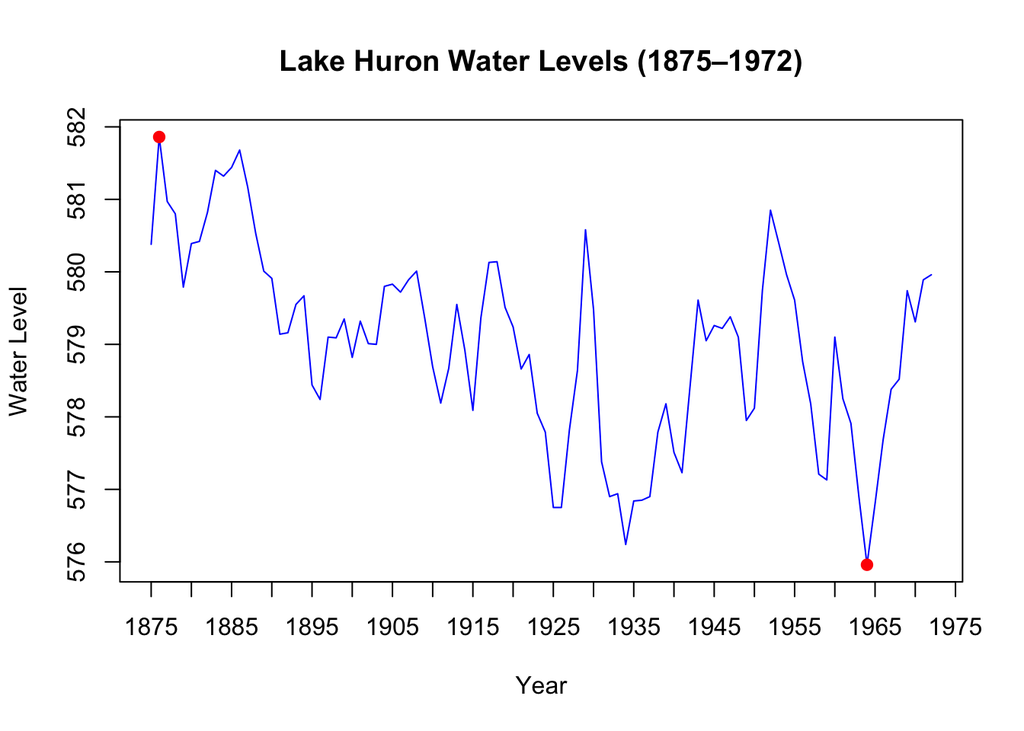

```r
plot(LakeHuron, main = "Lake Huron Water Levels (1875–1972)",
     xlab = "Year", ylab = "Water Level", col = "blue", type = "l", xaxt = "n")
axis(1, at = seq(1875, 1975, by = 5), labels = seq(1875, 1975, by = 5))

# Min and max values
points(time(LakeHuron)[which.min(LakeHuron)], levels_result$min, col = "red", pch = 19)
points(time(LakeHuron)[which.max(LakeHuron)], levels_result$max, col = "red", pch = 19)
```

Upon examining the lowest recorded values (the valleys on the plot), it appears that over time the lowest recorded water level was being pushed further and further down.

# 4 Titanic Survival Analysis

## 4.1 Data Exploration

```r
str(Titanic)
```

```
##  'table' num [1:4, 1:2, 1:2, 1:2] 0 0 35 0 0 0 17 0 118 154 ...
##  - attr(*, "dimnames")=List of 4
##   ..$ Class   : chr [1:4] "1st" "2nd" "3rd" "Crew"
##   ..$ Sex     : chr [1:2] "Male" "Female"
##   ..$ Age     : chr [1:2] "Child" "Adult"
##   ..$ Survived: chr [1:2] "No" "Yes"
```

```r
summary(Titanic)
```

```
## Number of cases in table: 2201
## Number of factors: 4
## Test for independence of all factors:
##  Chisq = 1637.4, df = 25, p-value = 0
##  Chi-squared approximation may be incorrect
```

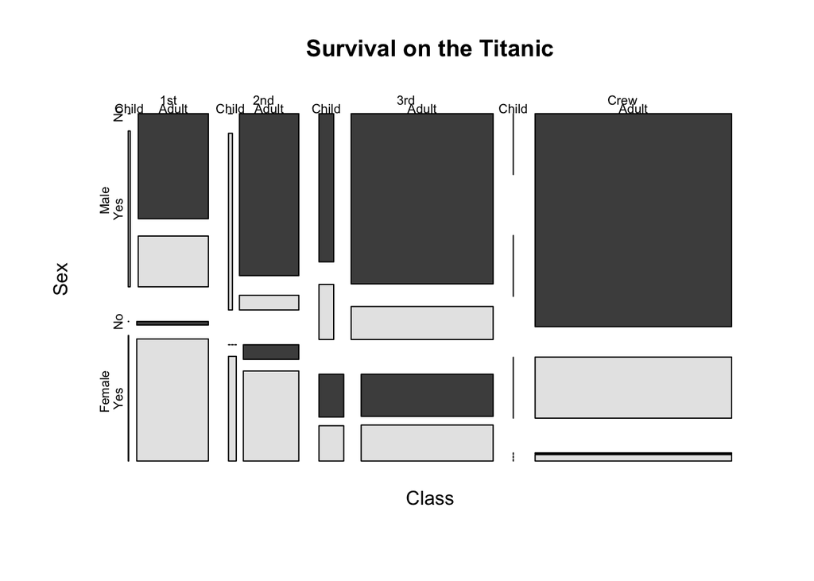

```r
mosaicplot(Titanic, main ="Survival on the Titanic", color = TRUE)
```

```r
apply(Titanic, c(1,2,3,4), sum)
```

```
## , , Age = Child, Survived = No
##
##       Sex
## Class  Male Female
##   1st     0      0
##   2nd     0      0
##   3rd    35     17
##   Crew    0      0
##
## , , Age = Adult, Survived = No
##
##       Sex
## Class  Male Female
##   1st   118      4
##   2nd   154     13
##   3rd   387     89
##   Crew  670      3
##
## , , Age = Child, Survived = Yes
##
##       Sex
## Class  Male Female
##   1st     5      1
##   2nd    11     13
##   3rd    13     14
##   Crew    0      0
##
## , , Age = Adult, Survived = Yes
##
##       Sex
## Class  Male Female
##   1st    57    140
##   2nd    14     80
##   3rd    75     76
##   Crew  192     20
```

The dataset “Titanic” represents the survivors/non-survivors of the Titanic. They are divided into Sex (female-male), Class (1st, 2nd, 3rd, Crew), Age (Child, Adults) and Survival (Yes, No). An overview of this data can be seen in the mosaic plot.

## 4.2 Impact of Age, Sex and Class on Survival

```
##        Survived
## Age       No Yes
##   Child   52  57
##   Adult 1438 654
```

```
##         Survived
## Sex        No Yes
##   Male   1364 367
##   Female  126 344
```

```
##       Survived
## Class   No Yes
##   1st  122 203
##   2nd  167 118
##   3rd  528 178
##   Crew 673 212
```

```
## , , Survived = No
##
##       Sex
## Class  Male Female
##   1st   118      4
##   2nd   154     13
##   3rd   422    106
##   Crew  670      3
##
## , , Survived = Yes
##
##       Sex
## Class  Male Female
##   1st    62    141
##   2nd    25     93
##   3rd    88     90
##   Crew  192     20
```

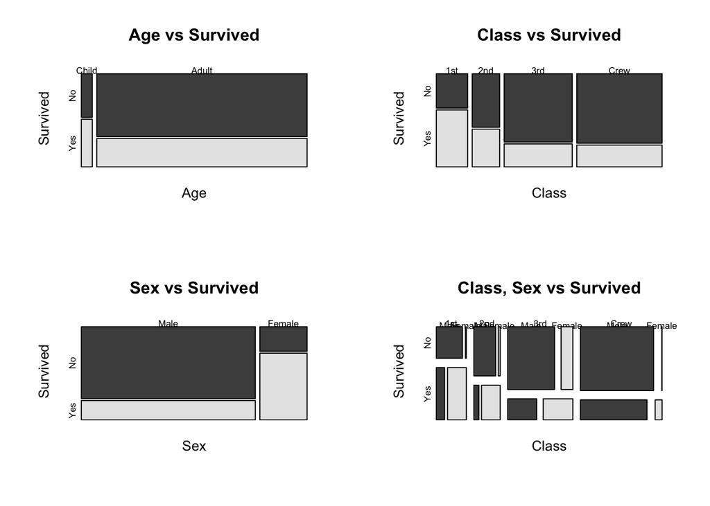

```
## , , Survived = No
##
##       Sex
## Class  Male Female
##   1st   118      4
##   2nd   154     13
##   3rd   422    106
##   Crew  670      3
##
## , , Survived = Yes
##
##       Sex
## Class  Male Female
##   1st    62    141
##   2nd    25     93
##   3rd    88     90
##   Crew  192     20
```

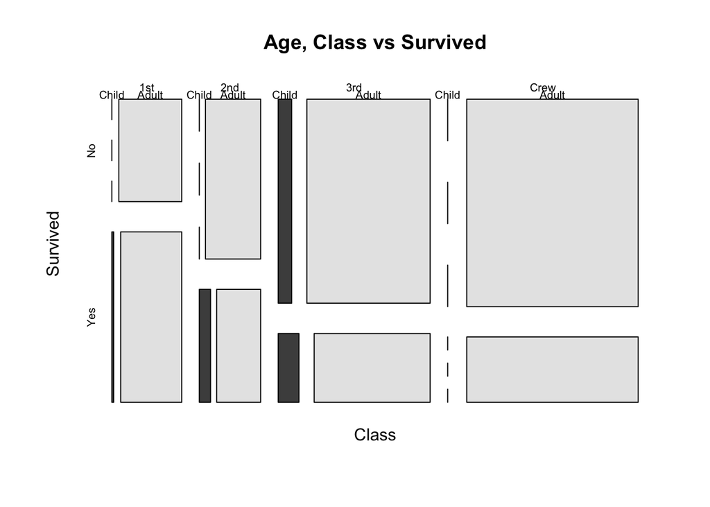

## 4.3 Simpson’s paradox & Interpretation

Simpson’s Paradox is a statistical phenomenon that occurs when subgroups are combined into one group. The process of aggregating data can cause the apparent direction and strength of the relationship between two variables to change.

In the case of our Titanic dataset one would think that the survival rate of the female crew was very low. But if we look at the “Sex vs. Survived” plot in general the females had a better survival outcome. This is because there were not many female crew members, but overall 20 out of 23 female crew members survived.

Furthermore if we only look at “Class vs. Survived” one could think, that the survival is independent from sex - so the the better the class, the better the survival outcome. But if we also include the sex, we see for example that the survival rate of females in the first class is almost 100%, whereas men in the first class only had a survival rate of about 34%.

Then if we look closely at the “Children in the Age vs. Survived” plot, we may think children do have a higher survival rate than adults. If we also include the class it becomes clear, that the survival rate of children is also very dependent on the class. The higher the class, the higher the survival rates in children.